# Analyzing Individual BGG Users

Phil Henrickson

2022-01-02

# **Mtorres760’s** BoardGameGeek Collection

This notebook contains a set of analyses for the selected user’s boardgamegeek collection. The bulk of the analysis is focused on building a user-specific predictive model to predict the games that Mtorres760 is likely to own. This enables to ask questions like, based on the games the user currently owns, what games are a good fit for their collection? What upcoming games are they likely to purchase?

This analysis is based on data from BoardGameGeek that was last updated on **2021-12-20.**

# 1 Collection Overview

We can look at a basic description of the number of games that the user owns, has rated, has previously owned, etc.

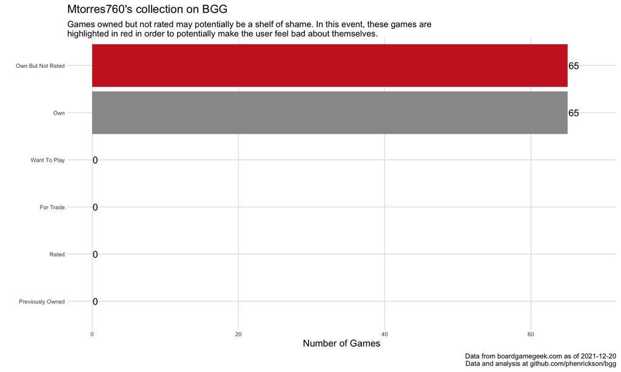

What years has the user owned/rated games from? While we can’t see when a user added or removed a game from their collection, we can look at their collection by the years in which their games were published.

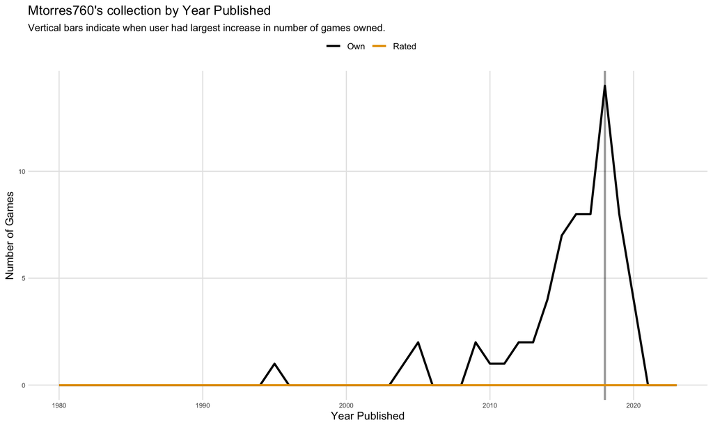

## 1.1 What types of games does Mtorres760 own?

We can look at the most frequent types of categories, mechanics, designers, and artists that appear in a user’s collection.

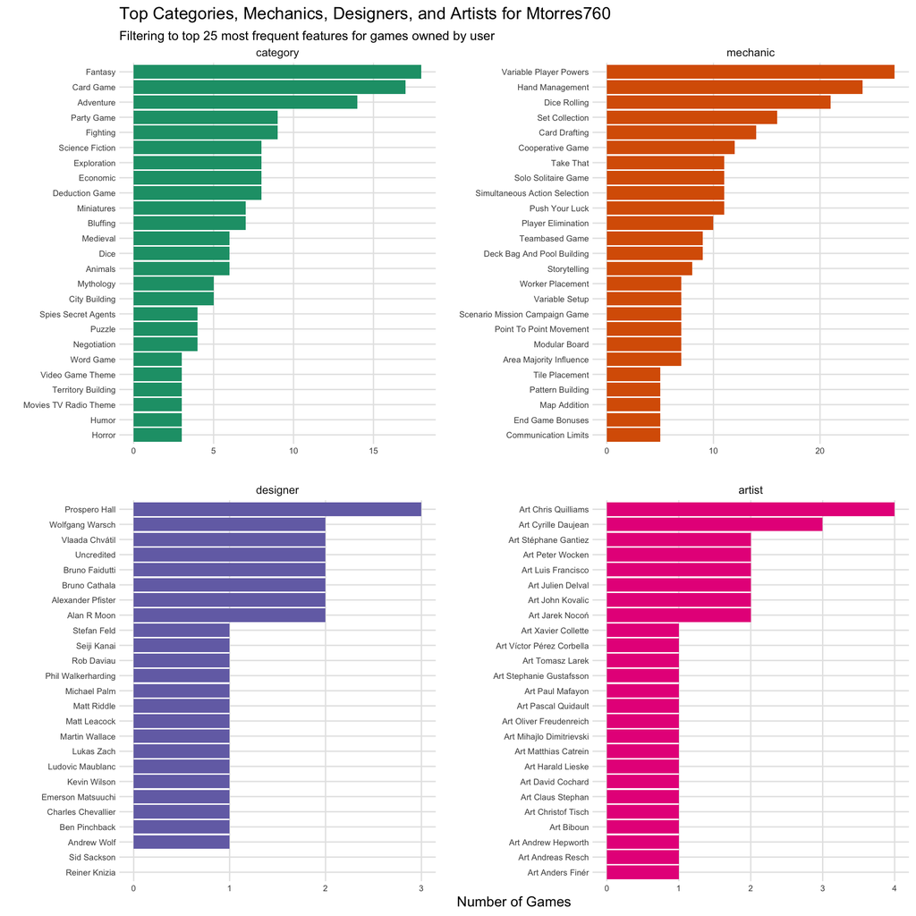

# 2 Modeling **Mtorres760’s** Collection

| username | dataset | period | games_owned | games_rated | games_played |
| --- | --- | --- | --- | --- | --- |
| Mtorres760 | training | published before 2020 | 61 | 0 | 61 |
| Mtorres760 | test | published 2020 or later | 4 | 0 | 4 |

There are two main (binary) outcomes we will be modeling for the user.

The first, **own** refers to whether the user currently lists a game as owned in their collection. The second, **played** refers to whether the user currently owns, has rated, or previously owned a game. This means the latter will generally have a larger list of games, but may still be a useful category to examine for people who play lots of games without necessarily owning them.

We will train predictive models to learn the probability that the user will own or play individual games based on their features.

## 2.1 Coefficients for Mtorres760

We can examine coefficients from the trained modes, which are penalized logistic regressions fit to our two main outcomes. Positive values indicate that a feature increases a user’s probabilility of owning/rating a game, while negative values indicate a feature decreases the probability.

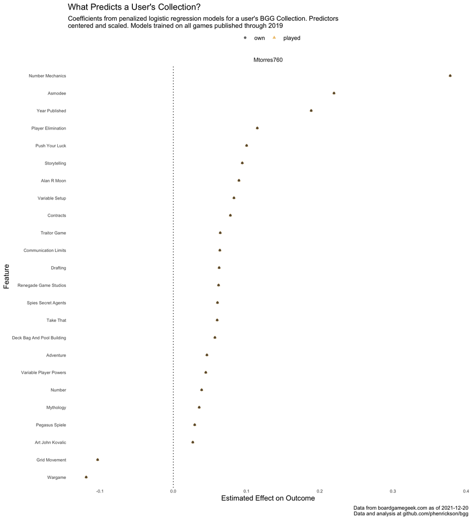

## 2.2 Visualizing Predictors for Mtorres760’s Collection

Why did the model identify these features? We can make density plots of the important features for predicting whether the user owned a game. Blue indicates the density for games owned by the user, while grey indicates the density for games not owned by the user.

[figure not shown]

Binary predictors can be difficult to see with this visualization, so we can also directly examine the percentage of games in a user’s collection with a predictor vs the percentage of all games with that predictor.

| username | Feature | % of Games with Feature In_Collection | % of Games with Feature All_Games | Ratio |
| --- | --- | --- | --- | --- |
| Mtorres760 | Traitor Game | 6.6% | 0.6% | 10.3 |
| Mtorres760 | Hidden Roles | 4.9% | 0.7% | 7.0 |
| Mtorres760 | Communication Limits | 6.6% | 1.0% | 6.8 |
| Mtorres760 | Contracts | 6.6% | 1.0% | 6.5 |
| Mtorres760 | Drafting | 6.6% | 1.0% | 6.4 |
| Mtorres760 | Variable Setup | 11.5% | 1.8% | 6.3 |
| Mtorres760 | Renegade Game Studios | 4.9% | 0.9% | 5.7 |
| Mtorres760 | Storytelling | 11.5% | 2.2% | 5.3 |
| Mtorres760 | Spies Secret Agents | 6.6% | 1.3% | 5.1 |
| Mtorres760 | Asmodee | 24.6% | 5.3% | 4.7 |
| Mtorres760 | Player Elimination | 16.4% | 3.9% | 4.2 |
| Mtorres760 | Mythology | 8.2% | 2.2% | 3.7 |
| Mtorres760 | Number | 3.3% | 0.9% | 3.6 |
| Mtorres760 | Push Your Luck | 18.0% | 5.2% | 3.4 |
| Mtorres760 | Alderac Entertainment Group | 4.9% | 1.5% | 3.2 |
| Mtorres760 | Deck Bag And Pool Building | 14.8% | 4.8% | 3.1 |
| Mtorres760 | Adventure | 19.7% | 6.6% | 3.0 |
| Mtorres760 | Pegasus Spiele | 13.1% | 4.7% | 2.8 |
| Mtorres760 | Word Game | 4.9% | 1.7% | 2.8 |
| Mtorres760 | Take That | 18.0% | 6.6% | 2.7 |
| Mtorres760 | Variable Player Powers | 41.0% | 16.9% | 2.4 |
| Mtorres760 | Simultaneous Action Selection | 16.4% | 7.1% | 2.3 |
| Mtorres760 | Grid Movement | 3.3% | 8.8% | 0.4 |
| Mtorres760 | Wargame | 0.0% | 12.5% | 0.0 |
| Mtorres760 | Race | 0.0% | 1.9% | 0.0 |

# 3 Assess Model’s Performance on Training Set

Before predicting games in upcoming years, we can examine how well the model did and what games it liked in the training set. In this case, we used resampling techniques (cross validation) to ensure that the model had not seen a game before making its predictions.

## 3.1 Separation Plot

An easy way to examine the performance of classification model is to view a separation plot. We plot the predicted probabilities from the model for every game (from resampling) from lowest to highest. We then overlay a blue line for any game that the user does own. A good classifier is one that is able to *separate* the blue (games owned by the user) from the white (games not owned by the user), with most of the blue occurring at the highest probabilities (right side of the chart).

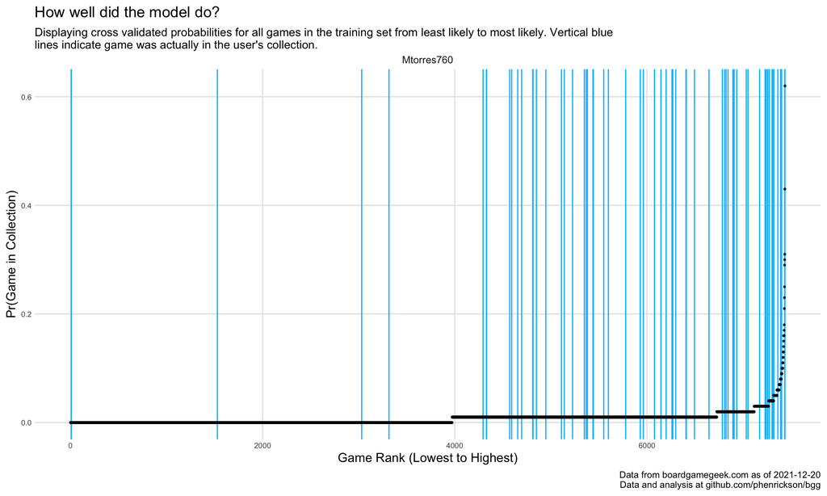

## 3.2 Top Games for **Mtorres760** from Training Set

We can display this information in table form, displaying the 100 games with the highest probability of ownership, adding a blue line when the user does own the game.

| username | yearpublished | game_id | name | pred_played | pred_own | actual_played | actual_own |
| --- | --- | --- | --- | --- | --- | --- | --- |
| Mtorres760 | 2018 | 205896 | Rising Sun | 0.62 | 0.62 | 0 | 0 |
| Mtorres760 | 2019 | 266507 | Clank!: Legacy – Acquisitions Incorporated | 0.43 | 0.43 | 1 | 1 |
| Mtorres760 | 2017 | 174430 | Gloomhaven | 0.31 | 0.31 | 1 | 1 |
| Mtorres760 | 2004 | 10547 | Betrayal at House on the Hill | 0.30 | 0.30 | 0 | 0 |
| Mtorres760 | 2008 | 37111 | Battlestar Galactica: The Board Game | 0.29 | 0.29 | 0 | 0 |
| Mtorres760 | 2014 | 157354 | Five Tribes | 0.25 | 0.25 | 0 | 0 |
| Mtorres760 | 2005 | 15062 | Shadows over Camelot | 0.23 | 0.23 | 0 | 0 |
| Mtorres760 | 2014 | 156129 | Deception: Murder in Hong Kong | 0.21 | 0.21 | 0 | 0 |
| Mtorres760 | 2019 | 264220 | Tainted Grail: The Fall of Avalon | 0.18 | 0.18 | 0 | 0 |
| Mtorres760 | 2019 | 283863 | The Magnificent | 0.17 | 0.17 | 0 | 0 |
| Mtorres760 | 2019 | 270971 | Era: Medieval Age | 0.16 | 0.16 | 0 | 0 |
| Mtorres760 | 2019 | 276025 | Maracaibo | 0.16 | 0.16 | 0 | 0 |
| Mtorres760 | 2017 | 188920 | This War of Mine: The Board Game | 0.16 | 0.16 | 0 | 0 |
| Mtorres760 | 2013 | 140620 | Lewis & Clark: The Expedition | 0.16 | 0.16 | 0 | 0 |
| Mtorres760 | 2019 | 285984 | Last Bastion | 0.15 | 0.15 | 0 | 0 |
| Mtorres760 | 2017 | 221805 | Breaking Bad: The Board Game | 0.14 | 0.14 | 0 | 0 |
| Mtorres760 | 2019 | 244820 | Posthuman Saga | 0.13 | 0.13 | 0 | 0 |
| Mtorres760 | 2013 | 127024 | Room 25 | 0.13 | 0.13 | 0 | 0 |
| Mtorres760 | 2018 | 167355 | Nemesis | 0.13 | 0.13 | 0 | 0 |
| Mtorres760 | 2014 | 154203 | Imperial Settlers | 0.12 | 0.12 | 0 | 0 |
| Mtorres760 | 2011 | 96848 | Mage Knight Board Game | 0.12 | 0.12 | 0 | 0 |
| Mtorres760 | 2019 | 257066 | Sierra West | 0.11 | 0.11 | 0 | 0 |
| Mtorres760 | 1979 | 22 | Magic Realm | 0.11 | 0.11 | 0 | 0 |
| Mtorres760 | 2019 | 266524 | PARKS | 0.11 | 0.11 | 0 | 0 |
| Mtorres760 | 2017 | 224037 | Codenames: Duet | 0.10 | 0.10 | 0 | 0 |
| Mtorres760 | 2017 | 175324 | Fog of Love | 0.10 | 0.10 | 0 | 0 |
| Mtorres760 | 2019 | 283294 | Yukon Airways | 0.10 | 0.10 | 0 | 0 |
| Mtorres760 | 2016 | 205158 | Codenames: Deep Undercover | 0.10 | 0.10 | 0 | 0 |
| Mtorres760 | 2018 | 225167 | Human Punishment: Social Deduction 2.0 | 0.10 | 0.10 | 0 | 0 |
| Mtorres760 | 2014 | 152241 | Ultimate Werewolf | 0.10 | 0.10 | 0 | 0 |

[output cut: 70 more lines]

We can also more formally assess how well the model did in resampling by looking at the area under the receiver operating characteristic. A perfect model would receive a score of 1, while a model that cannot predict the outcome will default to a score of 0.5. The extent to which something is a *good* score depends on the setting, but generally anything in the .8 to .9 range is very good while the .7 to .8 range is perfectly acceptable.

| username | outcome_type | .metric | .estimator | .estimate |
| --- | --- | --- | --- | --- |
| Mtorres760 | own | roc_auc | binary | 0.814 |
| Mtorres760 | played | roc_auc | binary | 0.814 |

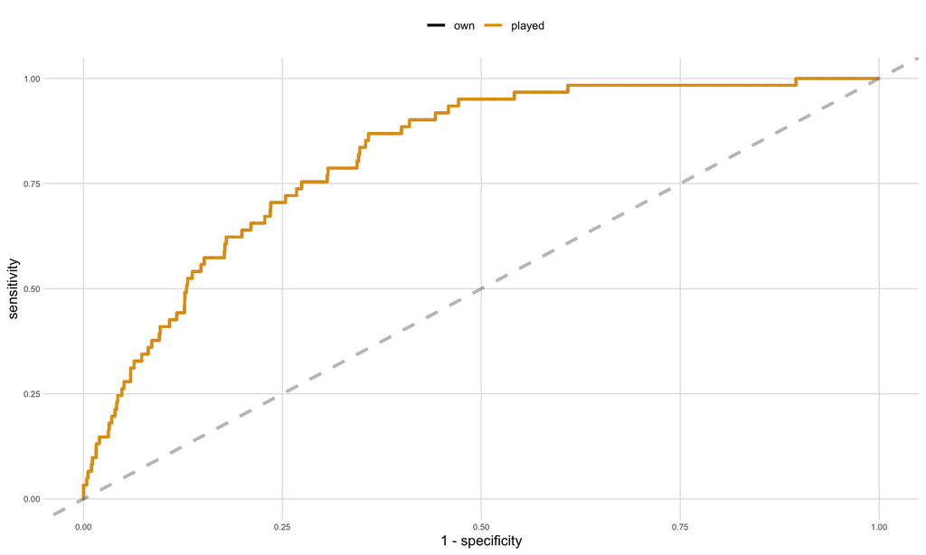

Another way to think about the model performance is to view its lift, or its ability to detect the positive outcomes over that of a null model. High lift indicates the model can much more quickly find all of the positive outcomes (in this case, games owned or played by the user), while a model with no lift is no better than random guessing.

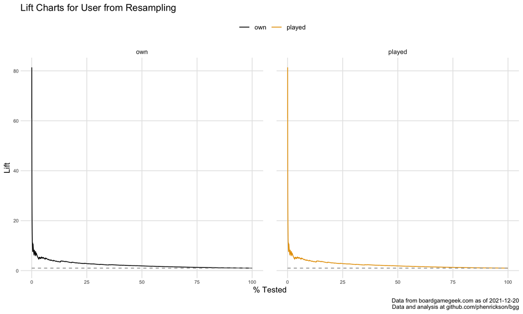

## 3.3 Most and Least Likely Games

What games does the model think Mtorres760 is **most likely to own** that are **not** in their collection?

| username | yearpublished | game_id | name | pred_own | actual_own |
| --- | --- | --- | --- | --- | --- |
| Mtorres760 | 2018 | 205896 | Rising Sun | 0.62 | 0 |
| Mtorres760 | 2004 | 10547 | Betrayal at House on the Hill | 0.30 | 0 |
| Mtorres760 | 2008 | 37111 | Battlestar Galactica: The Board Game | 0.29 | 0 |
| Mtorres760 | 2014 | 157354 | Five Tribes | 0.25 | 0 |
| Mtorres760 | 2005 | 15062 | Shadows over Camelot | 0.23 | 0 |

What games does the model think Mtorres760 is **least likely to own** that **are** in their collection?

| username | yearpublished | game_id | name | pred_own | actual_own |
| --- | --- | --- | --- | --- | --- |
| Mtorres760 | 2005 | 19796 | Cranium: The Family Fun Game | 0.00 | 1 |
| Mtorres760 | 2010 | 83919 | Scattergories Categories | 0.00 | 1 |
| Mtorres760 | 2019 | 274960 | Point Salad | 0.00 | 1 |
| Mtorres760 | 2019 | 271460 | UNO Flip! | 0.00 | 1 |
| Mtorres760 | 2011 | 84876 | The Castles of Burgundy | 0.01 | 1 |

## 3.4 Top Games by Year

Top 25 games most likely to be owned by the user in each year, highlighting in blue the games that the user has owned/played.

| rank | 2011 | 2012 | 2013 | 2014 | 2015 | 2016 | 2017 | 2018 | 2019 |
| --- | --- | --- | --- | --- | --- | --- | --- | --- | --- |
| 1 | Mage Knight Board Game | Space Cadets | Lewis & Clark: The Expedition | Five Tribes | Grand Austria Hotel | Codenames: Deep Undercover | Gloomhaven | Rising Sun | Clank!: Legacy – Acquisitions Incorporated |
| 2 | Panic Station | The Resistance: Avalon | Room 25 | Deception: Murder in Hong Kong | Argonauts | New Angeles | This War of Mine: The Board Game | Nemesis | Tainted Grail: The Fall of Avalon |
| 3 | Takenoko | Mice and Mystics | A Study in Emerald | Imperial Settlers | The King Is Dead | Virulence: An Infectious Card Game | Breaking Bad: The Board Game | Human Punishment: Social Deduction 2.0 | The Magnificent |
| 4 | A Few Acres of Snow | Wiz-War (Eighth Edition) | BANG! The Dice Game | Ultimate Werewolf | 504 | Hit Z Road | Codenames: Duet | Newton | Era: Medieval Age |
| 5 | Santiago de Cuba | Agents of SMERSH | LEADERS: The Combined Strategy Game | Patchwork | Blood Rage | Clank!: A Deck-Building Adventure | Fog of Love | Fireball Island: The Curse of Vul-Kar | Maracaibo |
| 6 | Ascension: Return of the Fallen | Seasons | Ultimate Werewolf: Inquisition | Spurs: A Tale in the Old West | Exploding Kittens | Islebound | Smash Up: What Were We Thinking? | Renegade | Last Bastion |
| 7 | Rory's Story Cubes: Voyages | Robinson Crusoe: Adventures on the Cursed Island | Impulse | Sons of Anarchy: Men of Mayhem | T.I.M.E Stories | Covert | Clank! In! Space!: A Deck-Building Adventure | Lords of Hellas | Posthuman Saga |
| 8 | A Game of Thrones: The Board Game (Second Edition) | Archipelago | Smash Up: Awesome Level 9000 | Istanbul | The Voyages of Marco Polo | Bloodborne: The Card Game | Summit: The Board Game | Vengeance | Sierra West |
| 9 | Skull | Dixit: Journey | Smash Up: The Obligatory Cthulhu Set | Port Royal | Mysterium | Terraforming Mars | Fallout | Kero | PARKS |
| 10 | Flash Point: Fire Rescue | Keyflower | Pathfinder Adventure Card Game: Rise of the Runelords – Base Set | Hyperborea | Watson & Holmes | The Oregon Trail Card Game | Secrets | Stuffed Fables | Yukon Airways |
| 11 | Dungeon Raiders | The Manhattan Project | Prosperity | Colt Express | A Study in Emerald (Second Edition) | Black Orchestra | Pandemic Legacy: Season 2 | The Grizzled: Armistice Edition | Amul |
| 12 | Nightfall | Urbion | Mascarade | King of New York | Exploding Kittens: NSFW Deck | Smash Up: It's Your Fault! | Clans of Caledonia | Gingerbread House | Tiny Towns |
| 13 | Martian Dice | Il Vecchio | Concept | Smash Up: Science Fiction Double Feature | Salem 1692 | Inis | Mythic Battles: Pantheon | Street Masters | The Lord of the Rings: Journeys in Middle-Earth |
| 14 | Pantheon | Smash Up | Rory's Story Cubes: Prehistoria | Sheep & Thief | One Night Ultimate Werewolf: Daybreak | Mistfall: Heart of the Mists | First Martians: Adventures on the Red Planet | Who Goes There? | Barrage |
| 15 | Village | Teomachia | Munchkin Legends | La Granja | Coffee Roaster | Sherlock Holmes Consulting Detective: Jack the Ripper & West End Adventures | Heaven & Ale | Decrypto | Spire's End |
| 16 | Ascension: Storm of Souls | Zombicide | Dungeon Twister: The Card Game | One Night Ultimate Werewolf | I, Spy | Burke's Gambit | Gaia Project | Betrayal Legacy | Century: A New World |
| 17 | Ultimate Warriorz | Libertalia | The Ravens of Thri Sahashri | Legendary Encounters: An Alien Deck Building Game | Above and Below | Exceed Fighting System | Spirit Island | Carthage | Black Angel |
| 18 | Dixit: Odyssey | Android: Infiltration | BioShock Infinite: The Siege of Columbia | Smash Up: Monster Smash | Runebound (Third Edition) | Aeon's End | Outlive | The Order of Vampire Hunters | The King's Dilemma |
| 19 | Dark Moon | Coup | Asgard's Chosen | DungeonQuest Revised Edition | Raiders of the North Sea | Harry Potter: Hogwarts Battle | The 7th Continent | Root | Circadians: First Light |
| 20 | Munchkin Zombies | Zug um Zug: Deutschland | Warhammer: Diskwars | Nations: The Dice Game | Mombasa | Agricola (Revised Edition) | Sherlock Holmes Consulting Detective: Carlton House & Queen's Park | Everdell | Middara: Unintentional Malum – Act 1 |
| 21 | Eclipse | Lords of Waterdeep | Legacy: The Testament of Duke de Crecy | Witness | Unspeakable Words: Deluxe Edition | When I Dream | Codenames: Marvel | Battlestar Galactica: Starship Battles – Starter Set | Herbaceous Sprouts |
| 22 | Dungeon Fighter | Escape: The Curse of the Temple | Firefly: The Game | Camel Up | Zombicide Season 3: Rue Morgue | Conan | Richard the Lionheart | Heroes of Terrinoth | Hellenica: Story of Greece |
| 23 | Mundus Novus | Serenissima (Second Edition) | The Doom That Came to Atlantic City | Spyfall | Homeland: The Game | 13 Days: The Cuban Missile Crisis | Betrayal at Baldur's Gate | Century: Eastern Wonders | God of War: The Card Game |
| 24 | King of Tokyo | War of the Ring: Second Edition | Empire Engine | Stay Away! | Grimslingers | Smash Up: Cease and Desist | Twilight Imperium: Fourth Edition | Blue Lagoon | Pandemic: Rapid Response |
| 25 | Munchkin Axe Cop | Among the Stars | City of Iron | Marrying Mr. Darcy | Elfenroads | Roll Player | Exploding Kittens: Party Pack | Boss Monster: Rise of the Minibosses | Arena: The Contest |

## 3.5 Interactive Predictions from Resampling

Interactive table for predictions from resampling.

|  | username | yearpublished | rank | game_id | name | pred_played | pred_own | actual_played | actual_own |
| --- | --- | --- | --- | --- | --- | --- | --- | --- | --- |
| 1 | Mtorres760 | 1900 | 2437 | 15878 | Rummy | 0.01 | 0.01 | 0 | 0 |
| 2 | Mtorres760 | 1900 | 2583 | 45 | Perudo | 0.01 | 0.01 | 0 | 0 |
| 3 | Mtorres760 | 1900 | 3479 | 5546 | Marbles | 0 | 0 | 0 | 0 |
| 4 | Mtorres760 | 1900 | 3482 | 11901 | Tic-Tac-Toe | 0 | 0 | 0 | 0 |
| 5 | Mtorres760 | 1900 | 3523 | 188 | Go | 0 | 0 | 0 | 0 |
| 6 | Mtorres760 | 1900 | 3616 | 171 | Chess | 0 | 0 | 0 | 0 |
| 7 | Mtorres760 | 1900 | 3625 | 2065 | Shogi | 0 | 0 | 0 | 0 |
| 8 | Mtorres760 | 1900 | 3626 | 2393 | Xiangqi | 0 | 0 | 0 | 0 |
| 9 | Mtorres760 | 1900 | 3795 | 26952 | International Checkers | 0 | 0 | 0 | 0 |
| 10 | Mtorres760 | 1900 | 3818 | 1602 | The Royal Game of Ur | 0 | 0 | 0 | 0 |

[output cut: 7426 more lines]

# 4 Validating the Model on 2020

How well did a model trained on a user’s collection through 2019 perform in predicting games for the user from 2020?

| username | outcome_type | yearpublished | .metric | .estimator | .estimate |
| --- | --- | --- | --- | --- | --- |
| Mtorres760 | own | 2020 | roc_auc | binary | 0.664 |
| Mtorres760 | played | 2020 | roc_auc | binary | 0.664 |

Table of top 25 games from 2020, highlighting games that the user owns.

| username | yearpublished | game_id | name | pred_own | pred_played | actual_own | actual_played |
| --- | --- | --- | --- | --- | --- | --- | --- |
| Mtorres760 | 2020 | 291457 | Gloomhaven: Jaws of the Lion | 0.21 | 0.21 | 1 | 1 |
| Mtorres760 | 2020 | 184267 | On Mars | 0.15 | 0.15 | 0 | 0 |
| Mtorres760 | 2020 | 292333 | Cowboys II: Cowboys & Indians Edition | 0.10 | 0.10 | 0 | 0 |
| Mtorres760 | 2020 | 256317 | Guild Master | 0.09 | 0.09 | 0 | 0 |
| Mtorres760 | 2020 | 302723 | Forgotten Waters | 0.07 | 0.07 | 1 | 1 |
| Mtorres760 | 2020 | 304434 | Victim: The Cursed Forest | 0.07 | 0.07 | 0 | 0 |
| Mtorres760 | 2020 | 315196 | Dungeons & Dragons: Adventure Begins | 0.07 | 0.07 | 0 | 0 |
| Mtorres760 | 2020 | 262274 | D6: Dungeons, Dudes, Dames, Danger, Dice and Dragons! | 0.06 | 0.06 | 0 | 0 |
| Mtorres760 | 2020 | 289939 | Goblin Teeth | 0.06 | 0.06 | 0 | 0 |
| Mtorres760 | 2020 | 301767 | Mysterium Park | 0.06 | 0.06 | 0 | 0 |
| Mtorres760 | 2020 | 302465 | Obsidia | 0.06 | 0.06 | 0 | 0 |
| Mtorres760 | 2020 | 316554 | Dune: Imperium | 0.06 | 0.06 | 0 | 0 |
| Mtorres760 | 2020 | 295905 | Cosmic Frog | 0.05 | 0.05 | 0 | 0 |
| Mtorres760 | 2020 | 302840 | Carcata | 0.05 | 0.05 | 0 | 0 |
| Mtorres760 | 2020 | 306040 | Merv: The Heart of the Silk Road | 0.05 | 0.05 | 0 | 0 |
| Mtorres760 | 2020 | 307844 | Atheneum: Mystic Library | 0.05 | 0.05 | 0 | 0 |
| Mtorres760 | 2020 | 314040 | Pandemic Legacy: Season 0 | 0.05 | 0.05 | 0 | 0 |
| Mtorres760 | 2020 | 316377 | 7 Wonders (Second Edition) | 0.05 | 0.05 | 0 | 0 |
| Mtorres760 | 2020 | 296151 | Viscounts of the West Kingdom | 0.04 | 0.04 | 0 | 0 |
| Mtorres760 | 2020 | 296892 | Sacred Rites | 0.04 | 0.04 | 0 | 0 |
| Mtorres760 | 2020 | 297030 | Tekhenu: Obelisk of the Sun | 0.04 | 0.04 | 0 | 0 |
| Mtorres760 | 2020 | 300322 | Hallertau | 0.04 | 0.04 | 0 | 0 |
| Mtorres760 | 2020 | 301880 | Raiders of Scythia | 0.04 | 0.04 | 0 | 0 |
| Mtorres760 | 2020 | 302425 | Unlock!: Mythic Adventures | 0.04 | 0.04 | 0 | 0 |
| Mtorres760 | 2020 | 302809 | Betrayal at Mystery Mansion | 0.04 | 0.04 | 0 | 0 |

# 5 Predicting Upcoming Games (2020 and On) for **Mtorres760**

Examine the top games for the test set.

| username | yearpublished | game_id | name | rank | own | played |
| --- | --- | --- | --- | --- | --- | --- |
| Mtorres760 | 2020 | 291457 | Gloomhaven: Jaws of the Lion | 1 | 0.21 | 0.21 |
| Mtorres760 | 2020 | 184267 | On Mars | 2 | 0.15 | 0.15 |
| Mtorres760 | 2020 | 292333 | Cowboys II: Cowboys & Indians Edition | 3 | 0.10 | 0.10 |
| Mtorres760 | 2020 | 256317 | Guild Master | 4 | 0.09 | 0.09 |
| Mtorres760 | 2020 | 302723 | Forgotten Waters | 5 | 0.07 | 0.07 |
| Mtorres760 | 2020 | 315196 | Dungeons & Dragons: Adventure Begins | 6 | 0.07 | 0.07 |
| Mtorres760 | 2020 | 304434 | Victim: The Cursed Forest | 7 | 0.07 | 0.07 |
| Mtorres760 | 2020 | 302465 | Obsidia | 8 | 0.06 | 0.06 |
| Mtorres760 | 2020 | 316554 | Dune: Imperium | 9 | 0.06 | 0.06 |
| Mtorres760 | 2020 | 301767 | Mysterium Park | 10 | 0.06 | 0.06 |
| Mtorres760 | 2020 | 262274 | D6: Dungeons, Dudes, Dames, Danger, Dice and Dragons! | 11 | 0.06 | 0.06 |
| Mtorres760 | 2020 | 289939 | Goblin Teeth | 12 | 0.06 | 0.06 |
| Mtorres760 | 2020 | 306040 | Merv: The Heart of the Silk Road | 13 | 0.05 | 0.05 |
| Mtorres760 | 2020 | 314040 | Pandemic Legacy: Season 0 | 14 | 0.05 | 0.05 |
| Mtorres760 | 2020 | 316377 | 7 Wonders (Second Edition) | 15 | 0.05 | 0.05 |
| Mtorres760 | 2020 | 295905 | Cosmic Frog | 16 | 0.05 | 0.05 |
| Mtorres760 | 2020 | 307844 | Atheneum: Mystic Library | 17 | 0.05 | 0.05 |
| Mtorres760 | 2020 | 302840 | Carcata | 18 | 0.05 | 0.05 |
| Mtorres760 | 2020 | 297030 | Tekhenu: Obelisk of the Sun | 19 | 0.04 | 0.04 |
| Mtorres760 | 2020 | 302425 | Unlock!: Mythic Adventures | 20 | 0.04 | 0.04 |
| Mtorres760 | 2020 | 296151 | Viscounts of the West Kingdom | 21 | 0.04 | 0.04 |
| Mtorres760 | 2020 | 302809 | Betrayal at Mystery Mansion | 22 | 0.04 | 0.04 |
| Mtorres760 | 2020 | 319966 | The King Is Dead: Second Edition | 23 | 0.04 | 0.04 |
| Mtorres760 | 2020 | 296892 | Sacred Rites | 24 | 0.04 | 0.04 |
| Mtorres760 | 2020 | 300322 | Hallertau | 25 | 0.04 | 0.04 |
| Mtorres760 | 2021 | 251661 | Oathsworn: Into the Deepwood | 1 | 0.15 | 0.15 |
| Mtorres760 | 2021 | 291847 | Mantis Falls | 2 | 0.12 | 0.12 |
| Mtorres760 | 2021 | 298102 | Roll Camera!: The Filmmaking Board Game | 3 | 0.11 | 0.11 |
| Mtorres760 | 2021 | 291859 | Riftforce | 4 | 0.10 | 0.10 |
| Mtorres760 | 2021 | 343905 | Boonlake | 5 | 0.10 | 0.10 |
| Mtorres760 | 2021 | 291572 | Oath: Chronicles of Empire and Exile | 6 | 0.09 | 0.09 |
| Mtorres760 | 2021 | 285967 | Ankh: Gods of Egypt | 7 | 0.09 | 0.09 |
| Mtorres760 | 2021 | 273330 | Bloodborne: The Board Game | 8 | 0.08 | 0.08 |
| Mtorres760 | 2021 | 310100 | Nemesis: Lockdown | 9 | 0.07 | 0.07 |
| Mtorres760 | 2021 | 316287 | Quest | 10 | 0.07 | 0.07 |
| Mtorres760 | 2021 | 340466 | Unfathomable | 11 | 0.06 | 0.06 |
| Mtorres760 | 2021 | 319999 | Dungeon Decorators | 12 | 0.05 | 0.05 |
| Mtorres760 | 2021 | 247417 | Solomon Kane | 13 | 0.05 | 0.05 |
| Mtorres760 | 2021 | 340677 | Bad Company | 14 | 0.05 | 0.05 |
| Mtorres760 | 2021 | 320992 | The Specialists | 15 | 0.05 | 0.05 |
| Mtorres760 | 2021 | 252752 | Genotype: A Mendelian Genetics Game | 16 | 0.05 | 0.05 |
| Mtorres760 | 2021 | 275557 | The Last Bottle of Rum | 17 | 0.04 | 0.04 |
| Mtorres760 | 2021 | 339906 | The Hunger | 18 | 0.04 | 0.04 |
| Mtorres760 | 2021 | 295785 | Euthia: Torment of Resurrection | 19 | 0.04 | 0.04 |
| Mtorres760 | 2021 | 325414 | Happy Little Dinosaurs | 20 | 0.04 | 0.04 |
| Mtorres760 | 2021 | 313730 | Harsh Shadows | 21 | 0.04 | 0.04 |
| Mtorres760 | 2021 | 331635 | Kameloot | 22 | 0.04 | 0.04 |
| Mtorres760 | 2021 | 300217 | Merchants of the Dark Road | 23 | 0.04 | 0.04 |
| Mtorres760 | 2021 | 306202 | Philosophia: Floating World | 24 | 0.04 | 0.04 |
| Mtorres760 | 2021 | 340237 | Wonder Book | 25 | 0.04 | 0.04 |
| Mtorres760 | 2022 | 331106 | The Witcher: Old World | 1 | 0.22 | 0.22 |
| Mtorres760 | 2022 | 317511 | Tindaya | 2 | 0.13 | 0.13 |
| Mtorres760 | 2022 | 295770 | Frosthaven | 3 | 0.10 | 0.10 |
| Mtorres760 | 2022 | 283137 | Human Punishment: The Beginning | 4 | 0.10 | 0.10 |
| Mtorres760 | 2022 | 256680 | Return to Dark Tower | 5 | 0.07 | 0.07 |
| Mtorres760 | 2022 | 322524 | Bardsung | 6 | 0.07 | 0.07 |
| Mtorres760 | 2022 | 273814 | Deliverance | 7 | 0.06 | 0.06 |
| Mtorres760 | 2022 | 340325 | Vagrantsong | 8 | 0.05 | 0.05 |
| Mtorres760 | 2022 | 322289 | Darwin's Journey | 9 | 0.04 | 0.04 |
| Mtorres760 | 2022 | 334065 | Verdant | 10 | 0.04 | 0.04 |
| Mtorres760 | 2022 | 274471 | Malhya: Lands of Legends | 11 | 0.04 | 0.04 |
| Mtorres760 | 2022 | 319807 | Shogun no Katana | 12 | 0.03 | 0.03 |
| Mtorres760 | 2022 | 305462 | The Age of Atlantis | 13 | 0.03 | 0.03 |
| Mtorres760 | 2022 | 338067 | 6: Siege – The Board Game | 14 | 0.03 | 0.03 |
| Mtorres760 | 2022 | 299106 | Fractal: Beyond the Void | 15 | 0.03 | 0.03 |
| Mtorres760 | 2022 | 311823 | Nova Aetas Renaissance | 16 | 0.03 | 0.03 |
| Mtorres760 | 2022 | 317321 | Darkest Dungeon: The Board Game | 17 | 0.03 | 0.03 |
| Mtorres760 | 2022 | 277025 | Vampire: The Masquerade – CHAPTERS | 18 | 0.03 | 0.03 |
| Mtorres760 | 2022 | 304051 | Creature Comforts | 19 | 0.03 | 0.03 |
| Mtorres760 | 2022 | 281647 | Stellaris: Infinite Legacy | 20 | 0.02 | 0.02 |
| Mtorres760 | 2022 | 305096 | Endless Winter: Paleoamericans | 21 | 0.02 | 0.02 |
| Mtorres760 | 2022 | 336986 | Flamecraft | 22 | 0.02 | 0.02 |
| Mtorres760 | 2022 | 312959 | Rallyman: DIRT | 23 | 0.02 | 0.02 |
| Mtorres760 | 2022 | 342444 | Black Rose Wars: Rebirth | 24 | 0.02 | 0.02 |
| Mtorres760 | 2022 | 325494 | ISS Vanguard | 25 | 0.02 | 0.02 |

## 5.1 Interactive Table for Upcoming Games 2020 and On

|  | username | yearpublished | game_id | name | rank | own | played |
| --- | --- | --- | --- | --- | --- | --- | --- |
| 1 | Mtorres760 | 2022 | 331106 | The Witcher: Old World | 1 | 0.22 | 0.22 |
| 2 | Mtorres760 | 2020 | 291457 | Gloomhaven: Jaws of the Lion | 2 | 0.21 | 0.21 |
| 3 | Mtorres760 | 2020 | 184267 | On Mars | 3 | 0.15 | 0.15 |
| 4 | Mtorres760 | 2021 | 251661 | Oathsworn: Into the Deepwood | 4 | 0.15 | 0.15 |
| 5 | Mtorres760 | 2022 | 317511 | Tindaya | 5 | 0.13 | 0.13 |
| 6 | Mtorres760 | 2021 | 291847 | Mantis Falls | 6 | 0.12 | 0.12 |
| 7 | Mtorres760 | 2021 | 298102 | Roll Camera!: The Filmmaking Board Game | 7 | 0.11 | 0.11 |
| 8 | Mtorres760 | 2021 | 291859 | Riftforce | 8 | 0.1 | 0.1 |
| 9 | Mtorres760 | 2020 | 292333 | Cowboys II: Cowboys &amp; Indians Edition | 9 | 0.1 | 0.1 |
| 10 | Mtorres760 | 2022 | 295770 | Frosthaven | 10 | 0.1 | 0.1 |

[output cut: 1627 more lines]